# Raster Layers

02 June, 2026

To see more complete package documentation check out: https://pfrater.github.io/arcpullr/

`arcpullr` has the capability to query not only vector (Feature) layers, but also raster layers (both Map and Image service types). The syntax for these is generally the same as for the `get_layer_by_*` family of functions. Map and Image layers require a bounding box as part of the query, so both `get_map_layer` and `get_image_layer` have required arguments of a URL and an `sf` object. These functions pull the raster layers provided by the URL and return the layer as a SpatRaster object from the `terra` package.

## URL’s for examples

**Example Source Data**

```r
# WDNR Server
image_server <- "https://dnrmaps.wi.gov/arcgis_image/rest/services/"

# WI Landcover Type URL
landcover_path <- "DW_Land_Cover/EN_Land_Cover2_Lev2/MapServer"
landcover_url <- paste0(image_server, landcover_path)

# WI Leaf-off Aerial Imagery URL
wi_leaf_off_path <- "DW_Imagery/EN_Image_Basemap_Latest_Leaf_Off/ImageServer"
wi_aerial_imagery_url <- paste0(image_server, wi_leaf_off_path)

# the wis_poly polygon is available as an exported object in arcpullr
```

## Map Layers

The `get_map_layer` function takes a URL and an sf object. Since the query for this layer type on an ArcGIS REST Service requires a bounding box any sf object can be used (i.e. POLYGON, POINT, LINE, etc.) and a bounding box will be created using the extent of the shape.

The example below pulls Wisconsin landcover types and plots them in a map.

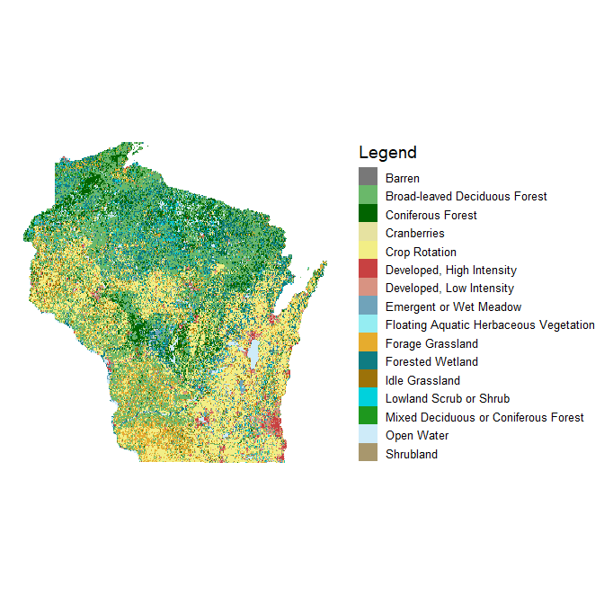

```r
wi_landcover <- get_map_layer(landcover_url, wis_poly)
plot_layer(wi_landcover)
```

## Image Layers

The `get_image_layer` function works the same as `get_map_layer` except that it queries from an Image layer. The easiest way to distinguish a Map layer from an Image layer is by checking the URL. Those from images will end with “ImageServer” whereas those from maps will end with “MapServer”. Another way to check is to look a the “Supported Operations” at the bottom of the actual web page on the ArcGIS REST Service. It will say either “Export Image” or “Export Map”.

This example pulls with Wisconsin Leaf-off Aerial Imagery dataset from the Wisconsin Department of Natural Resources.

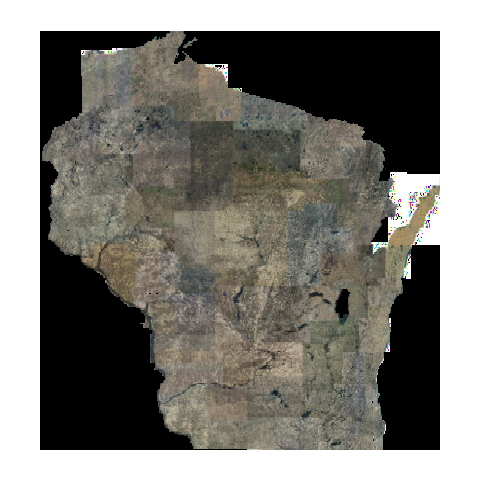